# Association Rules

25 de abril de 2021

## El problema Market-Basket

- Provista una base de datos de transacciones, encontrar reglas que predicirán la ocurrencia de un elemento basado en la ocurrencia de otros elementos en la transacción.
- La minería de conjuntos de elementos (itemsets) y reglas de asociación es un enfoque popular con amplia investigación para descubrir relaciones interesantes entre variables en bases de datos grandes.

## Ejemplo Market-Basket

Ejemplo de una base de datos de supermercado con cinco transacciones Transacciones Market-Basket

| TID | Items |
| --- | --- |
| 1 | milk, bread |
| 2 | bread, butter |
| 3 | beer |
| 4 | milk, bread, butter |
| 5 | bread, butter |

## Reglas de asociación

- Método de aprendizaje de máquina para descubrir relaciones interesantes entre variables en bases de datos grandes. Identifica reglas empleando métricas de interés.
- Desarrollado por Petr Hájek.
- Popularizado por Rakesh Agrawal, Tomasz Imieliński y Arun Swam durante los 90s por sus publicaciones relacionadas con el descubrimiento de tendencias en común entre productos en los registros de sistemas de punto de venta en supermercados.
- El orden de los elementos no es relevante para reglas de asociación.

## Aplicaciones de Reglas de Asociación

- Análisis Market-Basket en supermercados.
- Colocación de productos.
- Anuncios.
- Ventas.
- Cupones.
- Predicción de fallas en switches de telecomunicaciones.
- Minería de interacciones Web.

## Principales algoritmos de reglas de asociación

| Algoritmo | Descripción |
| --- | --- |
| Apriori | Emplea una estratrategia de amplitud primero para contar el soporte en itemsets y emplea una función de generación de candidatos que explota la propiedad de cierre del soporte de sus descendientes. |
| Eclat | Equivalence Class Transformation, es un algoritmo de profundidad primero basado en intersección de conjuntos. |

## Concepto y elementos de una regla de asociación

Regla de asociación: X => Y donde X, Y pertenecen a I.

I es un conjunto de elementos binarios, llamado items. D es un conjunto de transacciones, denominado base de datos.

Cada regla consta de dos conjuntos de elementos, conocidos como itemsets, X y Y.

X es el antecedente o lado izquierdo (left-hand-side, LHS). Y es el consecuente o lado derecho (right-hand-side, RHS).

Una regla requiere del soporte de una elevanda cantidad de transacciones para considerarse relevante estadísticamente.

## Ejemplos de reglas de asociación

{milk} => {bread}

{milk, bread} => {butter}

Nota: Las reglas de asociación cuentan con métricas de support, confidence, entre otras.

**Nota: La implicación significa co-ocurrencia, no causalidad.**

## Encontrar Reglas de Asociación

Enfoque de dos pasos:

1. Generación de itemsets frecuentes.
- Generar todos los itemsets donde support >= minsup.
1. Generación de reglas.
- Generar reglas de alta confianza para cada itemset frecuente, donde cada regla sea una partición binaria de un itemset frecuente.

¡La generación de itemsets es cara desde la perspectiva computacional!

## item

Un conjunto de atributos binarios I = {i2, i2, …, in}

Para el caso de nuestro ejemplo: I = {milk, bread, butter, beer}

## database

Conjunto de transacciones D = {t1, t2, …, tm}

Cada transacción en D tiene un ID único de transacción y contiene un subconjunto de los elementos en I.

## rule

Implicación de la forma X => Y donde X, Y <= I y X intersección Y = [conjunto vacío]

El conjunto de items (referidos como itemsets) X y Y se denominan antecedente (left-hand-side o LHs) y consecuente (right-hand-side o RHS) de la regla.

## Frequent Itemset

- itemset
- Colección de uno o más items
  - Ejemplo: a, b, c
- support Proporción de transacciones que contienen un itemset
- itemset frecuente
- Un itemset cuyo support sea mayor o igual a un umbral minsup

## Association Rule

- Association rule.
- Una expresión de implicación de la forma X -> Y, donde X y Y son itemsets.
- Ejemplo: {LHS} -> {RHS}
- Métricas de evaluación de reglas:
- support.
- confidence.

## Métricas de las reglas de asociación

[output not shown]

## Ejemplo de referencia

| ID de transacción | items |
| --- | --- |
| 1 | milk, bread |
| 2 | bread, butter |
| 3 | beer |
| 4 | milk, bread, butter |
| 5 | bread, butter |

Conjunto de items = I = {milk, bread, butter, beer} Número de transacciones = 5

## Support

Proporción de transacciones en el conjunto de datos que contienen el itemset.

p.e. considerando el ejemplo de referencia para el itemset X = {milk, bread} su support supp(X) es 2/5 = 0.4 debido a que el itemset {milk, bread} ocurre en el 40% de las transacciones.

## Confidence

Se interpreta como la probabilidad de encontrar el RHS (Y) de la regla en transacciones bajo la condición que éstas también incluyan LHS (X).

Formalmente, conf(X => Y) = supp(X unión Y) / supp(X)

p.e. considerando el ejemplo de referencia para la regla {milk, bread} => {butter} tiene una confianza de 0.5 es decir, en 50% de las transacciones que contienen milk y bread la regla es correcta (incluyen butter).

## Lift

## Requisitos de las reglas de asociación

Las reglas de asociación requieren que se cumpla con valores mínimos de support y confidence al mismo tiempo.

Los algoritmos de reglas de asociación requieren que el dataset cuente con atributos categóricos.

Se recomienda crear variables derivadas de tipo categórico cuando el dataset tenga atributos numéricos.

## Paquete arules (lenguaje R)

El paquete arules provee de infraestructura básica para crear y transformar datasets, así como para analizar los itemsets y reglas resultantes. arules también incluye interfaces a dos algorimos de minería rápida, implementaciones en lenguaje C de Apriori y Eclat por Christian Borgelt. Estos algoritmos pueden ser empleados para minar itemsets frecuentes, itemsets de frecuencia máxima, itemsets cerrados frecuentes y reglas de asociación.

- arules emplea representaciones de matrices dispersas para minimizar el consumo de memoria.
- Diseñado considerando extensibilidad tanto en interfaces con nuevos algoritmos y en la adición de nuevos tipos de métricas y asociaciones de interés.

## Métodos principales en arules

El resultado de minar datos de transacciones en a rules son asociaciones.

Conceptualmente, las asociaciones son un conjunto de objetos que describen las relaciones entre un conjunto de items (p.e. un itemset o una regla) que tienen asignados valores para distintas métricas de calidad (p.e. confidence y lift), o otras métricas (p.e. ingresos cubiertos por la asociación).

## Funcionalidad común en arules

- `summary()` provee de una panorama general de conjunto de datos e `inspect()` despliegan asociaciones individuales,
- `length()` para obtener el número de elementos de un set,
- `items()` para obtener para cada asociación un conjunto de elementos items involucrados en la asociación (p.e. la unión de items en el LHS y RHS por cada regla),
- `sort()` para ordenar el conjunto de datos set empleando valores de distintas métricas de calidad,
- extracción de subconjuntos por medio de `[]` y `()`,
- operación de conjuntos (`union()`, `intersect()`, `setequal()`), y
- encontrar los elementos que correspondan a dos conjuntos (`match()`).

## Carga de arules

```r
#install.packages("arules")
#install.packages("jsonlite")
#install.packages("arulesviz")
library("arules")
```

## Dataset AdultUCI

```r
data("AdultUCI")
AdultUCI[1:5,]
```

```
##   age        workclass fnlwgt education education-num     marital-status
## 1  39        State-gov  77516 Bachelors            13      Never-married
## 2  50 Self-emp-not-inc  83311 Bachelors            13 Married-civ-spouse
## 3  38          Private 215646   HS-grad             9           Divorced
## 4  53          Private 234721      11th             7 Married-civ-spouse
## 5  28          Private 338409 Bachelors            13 Married-civ-spouse
##          occupation  relationship  race    sex capital-gain capital-loss
## 1      Adm-clerical Not-in-family White   Male         2174            0
## 2   Exec-managerial       Husband White   Male            0            0
## 3 Handlers-cleaners Not-in-family White   Male            0            0
## 4 Handlers-cleaners       Husband Black   Male            0            0
## 5    Prof-specialty          Wife Black Female            0            0
##   hours-per-week native-country income
## 1             40  United-States  small
## 2             13  United-States  small
## 3             40  United-States  small
## 4             40  United-States  small
## 5             40           Cuba  small
```

## Panorama general AdultUCI

```r
summary(AdultUCI)
```

```
##       age                   workclass         fnlwgt
##  Min.   :17.00   Private         :33906   Min.   :  12285
##  1st Qu.:28.00   Self-emp-not-inc: 3862   1st Qu.: 117551
##  Median :37.00   Local-gov       : 3136   Median : 178145
##  Mean   :38.64   State-gov       : 1981   Mean   : 189664
##  3rd Qu.:48.00   Self-emp-inc    : 1695   3rd Qu.: 237642
##  Max.   :90.00   (Other)         : 1463   Max.   :1490400
##                  NA's            : 2799
##         education     education-num                 marital-status
##  HS-grad     :15784   Min.   : 1.00   Divorced             : 6633
##  Some-college:10878   1st Qu.: 9.00   Married-AF-spouse    :   37
##  Bachelors   : 8025   Median :10.00   Married-civ-spouse   :22379
##  Masters     : 2657   Mean   :10.08   Married-spouse-absent:  628
##  Assoc-voc   : 2061   3rd Qu.:12.00   Never-married        :16117
##  11th        : 1812   Max.   :16.00   Separated            : 1530
##  (Other)     : 7625                   Widowed              : 1518
##            occupation            relationship                   race
##  Prof-specialty : 6172   Husband       :19716   Amer-Indian-Eskimo:  470
##  Craft-repair   : 6112   Not-in-family :12583   Asian-Pac-Islander: 1519
##  Exec-managerial: 6086   Other-relative: 1506   Black             : 4685
##  Adm-clerical   : 5611   Own-child     : 7581   Other             :  406
##  Sales          : 5504   Unmarried     : 5125   White             :41762
##  (Other)        :16548   Wife          : 2331
##  NA's           : 2809
##      sex         capital-gain    capital-loss    hours-per-week
##  Female:16192   Min.   :    0   Min.   :   0.0   Min.   : 1.00
##  Male  :32650   1st Qu.:    0   1st Qu.:   0.0   1st Qu.:40.00
##                 Median :    0   Median :   0.0   Median :40.00
##                 Mean   : 1079   Mean   :  87.5   Mean   :40.42
##                 3rd Qu.:    0   3rd Qu.:   0.0   3rd Qu.:45.00
##                 Max.   :99999   Max.   :4356.0   Max.   :99.00
##
##        native-country    income
##  United-States:43832   small:24720
##  Mexico       :  951   large: 7841
##  Philippines  :  295   NA's :16281
##  Germany      :  206
##  Puerto-Rico  :  184
##  (Other)      : 2517
##  NA's         :  857
```

## Preparación de un dataset para minado de asociaciones

- Eliminar datos de control interno, identificadores.
- Eliminar atributos duplicados.
- Transformar datos numéricos a categóricos.

## Preparación del dataset AdultUCI

- Eliminar: fnlwgt, education-num
- Transformar hours-per-week a un categórico ordenado

| Rango inferior | Rango superior | Etiqueta |
| --- | --- | --- |
| -Inf | 5 | Part-time |
| 5 | 40 | Full-time |
| 40 | 60 | Overtime |
| 60 | 168 | Workaholic |

## fnlwgt

```r
AdultUCI[["fnlwgt"]] <- NULL
```

## education-num

```r
AdultUCI[["education-num"]] <- NULL
```

## age

```r
AdultUCI[["age"]] <- ordered(cut(AdultUCI[["age"]], c(15, 25, 45, 65, 100)), labels = c("Young", "Middle-aged", "Senior", "Old"))
```

## hours-per-week

```r
AdultUCI[["hours-per-week"]] <- ordered(cut(AdultUCI[["hours-per-week"]], c(0, 5, 40, 60, 168)), labels = c("Part-time", "Full-time", "Over-time", "Workaholic"))
```

## capital-gain

```r
AdultUCI[["capital-gain"]] <- ordered(cut(AdultUCI[["capital-gain"]], c(-Inf, 0, median(AdultUCI[["capital-gain"]][AdultUCI[["capital-gain"]] > 0]), Inf)), labels=c("None", "Low", "High"))
```

## capital-loss

```r
AdultUCI[["capital-loss"]] <- ordered(cut(AdultUCI[["capital-loss"]], c(-Inf, 0, median(AdultUCI[["capital-loss"]][AdultUCI[["capital-loss"]] > 0 ]), Inf)), labels = c("none", "low", "high"))
```

## Invocamos transactions()

```r
AdultDev <- as(AdultUCI, "transactions")
```

## Inspeccionamos AdultDev

```r
summary(AdultDev)
```

```
## transactions as itemMatrix in sparse format with
##  48842 rows (elements/itemsets/transactions) and
##  115 columns (items) and a density of 0.1089939
##
## most frequent items:
##            capital-loss=none            capital-gain=None
##                        46560                        44807
## native-country=United-States                   race=White
##                        43832                        41762
##     hours-per-week=Full-time                      (Other)
##                        34172                       401067
##
## element (itemset/transaction) length distribution:
## sizes
##     9    10    11    12    13
##    19   971  2067 15623 30162
##
##    Min. 1st Qu.  Median    Mean 3rd Qu.    Max.
##    9.00   12.00   13.00   12.53   13.00   13.00
##
## includes extended item information - examples:
##            labels variables      levels
## 1       age=Young       age       Young
## 2 age=Middle-aged       age Middle-aged
## 3      age=Senior       age      Senior
##
## includes extended transaction information - examples:
##   transactionID
## 1             1
## 2             2
## 3             3
```

## Visualización de frecuencia de items

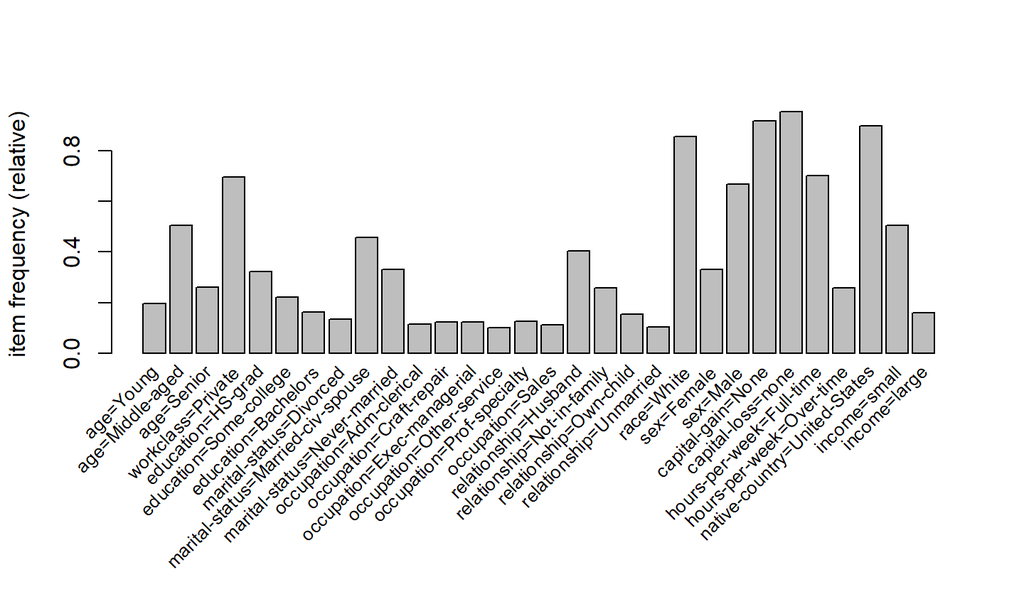

```r
itemFrequencyPlot(AdultDev[, itemFrequency(AdultDev)>0.1], cex.names = 0.8)
```

## Generación de reglas con el algoritmo apriori

```r
rules <- apriori(AdultDev, parameter = list(support = 0.01, confidence = 0.6))
```

```
## Apriori
##
## Parameter specification:
##  confidence minval smax arem  aval originalSupport maxtime support minlen
##         0.6    0.1    1 none FALSE            TRUE       5    0.01      1
##  maxlen target  ext
##      10  rules TRUE
##
## Algorithmic control:
##  filter tree heap memopt load sort verbose
##     0.1 TRUE TRUE  FALSE TRUE    2    TRUE
##
## Absolute minimum support count: 488
##
## set item appearances ...[0 item(s)] done [0.00s].
## set transactions ...[115 item(s), 48842 transaction(s)] done [0.05s].
## sorting and recoding items ... [66 item(s)] done [0.01s].
## creating transaction tree ... done [0.05s].
## checking subsets of size 1 2 3 4 5 6 7 8 9 10
```

```
##  done [1.04s].
## writing ... [292698 rule(s)] done [0.08s].
## creating S4 object  ... done [0.20s].
```

## Exploramos el objeto rules

```r
rules
```

```
## set of 292698 rules
```

## Resumen del objeto rules

```r
summary(rules)
```

```
## set of 292698 rules
##
## rule length distribution (lhs + rhs):sizes
##     1     2     3     4     5     6     7     8     9    10
##     7   446  5025 22355 53997 78352 71636 42102 15495  3283
##
##    Min. 1st Qu.  Median    Mean 3rd Qu.    Max.
##   1.000   5.000   6.000   6.341   7.000  10.000
##
## summary of quality measures:
##     support          confidence        coverage            lift
##  Min.   :0.01001   Min.   :0.6000   Min.   :0.01001   Min.   : 0.7171
##  1st Qu.:0.01257   1st Qu.:0.7839   1st Qu.:0.01472   1st Qu.: 1.0074
##  Median :0.01722   Median :0.9042   Median :0.02049   Median : 1.0535
##  Mean   :0.02749   Mean   :0.8628   Mean   :0.03254   Mean   : 1.3022
##  3rd Qu.:0.02819   3rd Qu.:0.9532   3rd Qu.:0.03366   3rd Qu.: 1.2980
##  Max.   :0.95328   Max.   :1.0000   Max.   :1.00000   Max.   :20.6826
##      count
##  Min.   :  489
##  1st Qu.:  614
##  Median :  841
##  Mean   : 1343
##  3rd Qu.: 1377
##  Max.   :46560
##
## mining info:
##      data ntransactions support confidence
##  AdultDev         48842    0.01        0.6
```

## Filtrado de objeto rules - ingreso menor

```r
rulesIncomeSmall <- subset(rules, subset = rhs %in% "income=small" & lift > 1.2)
```

## Detalle de reglas - ingreso menor

```r
inspect(sort(rulesIncomeSmall, by = "confidence")[1:3])
```

```
##     lhs                               rhs               support confidence   coverage     lift count
## [1] {age=Young,
##      workclass=Private,
##      marital-status=Never-married,
##      occupation=Adm-clerical,
##      race=White,
##      capital-gain=None,
##      hours-per-week=Full-time}     => {income=small} 0.01109701  0.7029831 0.01578559 1.388960   542
## [2] {age=Young,
##      workclass=Private,
##      marital-status=Never-married,
##      occupation=Adm-clerical,
##      race=White,
##      capital-gain=None,
##      capital-loss=none,
##      hours-per-week=Full-time}     => {income=small} 0.01085132  0.7029178 0.01543753 1.388831   530
## [3] {age=Young,
##      workclass=Private,
##      education=HS-grad,
##      marital-status=Never-married,
##      race=White,
##      sex=Male,
##      capital-gain=None,
##      capital-loss=none,
##      hours-per-week=Full-time}     => {income=small} 0.01070800  0.7010724 0.01527374 1.385185   523
```

## Filtrado de objeto rules - ingreso mayor

```r
rulesIncomeLarge <- subset(rules, subset = rhs %in% "income=large" & lift > 1.2)
```

## Detalle de reglas - ingreso mayor

```r
inspect(sort(rulesIncomeLarge, by = "confidence")[1:3])
```

```
##     lhs                                    rhs               support confidence   coverage     lift count
## [1] {marital-status=Married-civ-spouse,
##      capital-gain=High,
##      native-country=United-States}      => {income=large} 0.01562180  0.6849192 0.02280824 4.266398   763
## [2] {marital-status=Married-civ-spouse,
##      capital-gain=High,
##      capital-loss=none,
##      native-country=United-States}      => {income=large} 0.01562180  0.6849192 0.02280824 4.266398   763
## [3] {relationship=Husband,
##      race=White,
##      capital-gain=High,
##      native-country=United-States}      => {income=large} 0.01302158  0.6846071 0.01902052 4.264454   636
```

## Ejercicio AR-01

Obten el conjunto de reglas de asociación cuyo RHS sea workclass=Private y su lift sea mayor a 1.2

## Filtrado de objeto rules - sector laboral privado

```r
#Completa los parámetros de la siguiente línea
#rulesWorkClassPrivate <- subset(rules, subset = rhs %in% "" & lift >0)
```

## Ejercicio AR-02

```r
#"Completa los parámetros de la siguiente línea"
#inspect(sort(rulesWorkClassPrivate, by = "")[1:3])
```

## Ejercicio AR-03

Documenta los resultados de la invocación a inspect en una tabla en un documento PDF.